# R Notebook

```r
#Upload packages
library(tidyverse)
library(here)
library(patchwork)
```

```r
#Import data
chl <- read_csv(here("files", "chl_all_station_2024-10-25.csv"))
ctd <- read_csv(here("files", "kc10_profs_qc1.csv"))
ctd_r1 <- read_csv(here("outputs", "rvrs01_profs_qc1.csv"))
```

```r
distinct_sites <- chl %>%
  group_by(site_id) %>%
  summarise(n_samp = n(),
            min_dep = min(line_out_depth),
            max_dep = max(line_out_depth),
            min_date = min(date),
            max_date = max(date))
```

```r
#selecting KC10
kc <- chl %>%
  filter(site_id == "KC10" | site_id == "FZH01")

fz <- chl %>%
  filter(site_id == "FZH01")
```

```r
kc_flag <- kc %>%
  distinct(chla_flag)
```

```r
kc_qc <- kc %>%
  filter(!is.na(chla)) %>%
  filter(chla > 0) %>%
  filter(chla_flag == "AV" | chla_flag == "SVC" | is.na(chla_flag)) %>%
  filter(!filter_type == "Bulk GF/F") %>%
  group_by(site_id, date, line_out_depth) %>%
  mutate(n_filt = n()) %>%
  ungroup() %>%
  group_by(site_id, date, line_out_depth, filter_type) %>%
  mutate(n_type = n()) %>%
  ungroup() %>%
  filter(n_filt == 3 & n_type == 1) %>%
  group_by(site_id, date, line_out_depth, filter_type) %>%
  summarise(avg_chla = mean(chla)) %>%
  ungroup() %>%
  group_by(site_id, date, line_out_depth) %>%
  mutate(sum = sum(avg_chla)) %>%
  ungroup() %>%
  mutate(perc = avg_chla/sum) %>%
  select(date, site_id, depth = line_out_depth, filter_type, avg_chla, sum, perc) %>%
  mutate(filter_type2 = case_when(filter_type == "2um" ~ "3um",
                                  TRUE ~ as.character(filter_type)))
kc_bulk <- kc %>%
  filter(!is.na(chla)) %>%
  filter(chla_flag == "AV" | chla_flag == "SVC" | is.na(chla_flag)) %>%
  filter(filter_type == "Bulk GF/F") %>%
  group_by(site_id, date, line_out_depth, filter_type) %>%
  summarise(avg_chla = mean(chla)) %>%
  select(date, depth = line_out_depth, bulk = avg_chla)
kc_qc <- kc_qc %>%
  left_join(kc_bulk) %>%
  mutate(year = lubridate::year(date),
         month = lubridate::month(date))
```

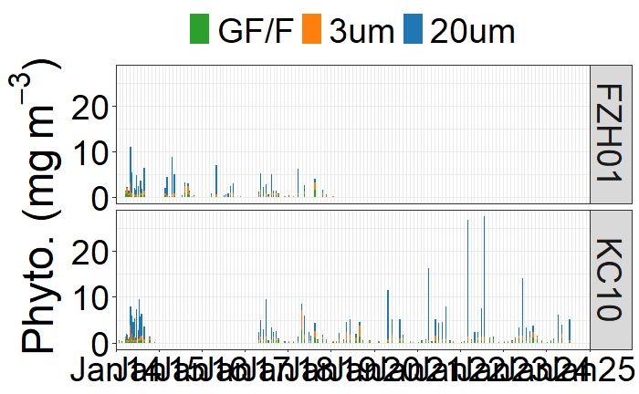

```r
kc_qc %>%
  filter(depth == 5) %>%
  ggplot(aes(x = date, y = avg_chla, fill = filter_type2)) +
  # geom_area() +
  geom_bar(position = "stack", stat = "identity", width = 10) +
  ggsci::scale_fill_d3() +
  facet_grid(site_id ~ .) +
  scale_x_date(breaks = seq(as.Date("2014-01-01"), as.Date("2025-01-01"),
                            by = "1 year"), date_minor_breaks = "1 month",
               expand = c(0, 0),
               date_labels = "%b%y",
               limits = c(as.Date("2014-01-01"), as.Date("2025-01-01"))) +
  theme_bw() +
  labs(y = bquote("Phyto. (mg" ~ m^-3*")"),
       fill = "Group") +
  theme(legend.position = "top",
        legend.direction = "horizontal",
        legend.title = element_blank(),
        text = element_text(size = 35), #35
        axis.text = element_text(color = "black"),
        axis.title.x = element_blank()) +
  guides(fill = guide_legend(nrow = 1, reverse = TRUE))

ggsave(here("figures", "timeseries_FZ01_KC10_5m.png"),
        width = 16, height = 7, dpi = 300)
```

```r
ts_1 <- kc_qc %>%
  ggplot() +
  # geom_area() +
  geom_bar(aes(x = date, y = avg_chla, fill = filter_type2),
           position = "stack", stat = "identity", width = 20) +
  # geom_smooth(aes(x = date, y = sum, color = as.factor(year)),
  #             method = "loess", span = 0.05) +
  ggsci::scale_fill_d3() +
  facet_grid(depth ~ ., scales = "free_y") +
  scale_x_date(breaks = seq(as.Date("2014-01-01"), as.Date("2025-01-01"),
                            by = "1 year"), date_minor_breaks = "1 month",
               expand = c(0, 0),
               date_labels = "%b%y",
               limits = c(as.Date("2014-01-01"), as.Date("2025-01-01"))) +
  theme_bw() +
  labs(y = bquote("Size Fractionated Chla (mg" ~ m^-3*")"),
       fill = "Group") +
  theme(legend.position = c(0.5, 0.95),
        legend.direction = "horizontal",
        legend.title = element_blank(),
        text = element_text(size = 35), #35
        axis.text = element_text(color = "black"),
        axis.title.x = element_blank()) +
  guides(fill = guide_legend(nrow = 1, reverse = TRUE))
```

```
A numeric `legend.position` argument in `theme()` was deprecated in ggplot2 3.5.0.
```

```r
# ggsave(here("figures", "timeseries_FZ01_KC10_5m.png"),
#         width = 16, height = 7, dpi = 300)
```

```r
ts_2 <- kc_qc %>%
  ggplot(aes(x = date, y = site_id, fill = site_id)) +
  geom_point(pch = 21, size = 8) +
  ggsci::scale_fill_jco() +
  scale_x_date(breaks = seq(as.Date("2014-01-01"), as.Date("2025-01-01"),
                            by = "1 year"), date_minor_breaks = "1 month",
               expand = c(0, 0),
               date_labels = "%b%y",
               limits = c(as.Date("2014-01-01"), as.Date("2025-01-01"))) +
  theme_bw() +
  theme(legend.position = "none",
        text = element_text(size = 35), #35
        axis.text = element_text(color = "black"),
        axis.title.y = element_blank(),
        axis.title.x = element_blank(),
        axis.text.x = element_blank())
```

```r
fig_cs <- ts_2 / ts_1 +
  plot_layout(heights = c(1, 10))
```

|  | t | l | b | r |
| --- | --- | --- | --- | --- |
| 1: | 1 | 1 | 1 | 1 |
| 2: | 1 | 2 | 1 | 2 |

```r
ggsave(here("figures", "timeseries_FZ01_KC10_5m.png"), fig_cs,
        width = 16, height = 14, dpi = 300)
```

```r
#Filtering for days when all 5 surface depths are available and then integrated them.
int <- kc_qc %>%
  filter(depth < 31) %>%
  group_by(date, site_id, filter_type2) %>%
  mutate(n = n()) %>%
  ungroup() %>%
  filter(n == 5) %>%
  group_by(date, site_id, filter_type2) %>%
  summarise(int = sum(avg_chla)) %>%
  ungroup()
```

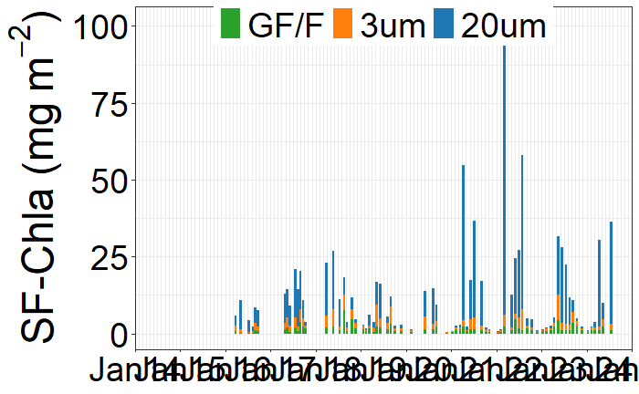

```r
int %>%
  ggplot() +
  # geom_area() +
  geom_bar(aes(x = date, y = int, fill = filter_type2),
           position = "stack", stat = "identity", width = 20) +
  # geom_smooth(aes(x = date, y = sum, color = as.factor(year)),
  #             method = "loess", span = 0.05) +
  ggsci::scale_fill_d3() +
  scale_x_date(breaks = seq(as.Date("2014-01-01"), as.Date("2025-01-01"),
                            by = "1 year"), date_minor_breaks = "1 month",
               expand = c(0, 0),
               date_labels = "%b%y",
               limits = c(as.Date("2014-01-01"), as.Date("2025-01-01"))) +
  theme_bw() +
  labs(y = bquote("SF-Chla (mg" ~ m^-2*")"),
       fill = "Group") +
  theme(legend.position = c(0.5, 0.95),
        legend.direction = "horizontal",
        legend.title = element_blank(),
        text = element_text(size = 35), #35
        axis.text = element_text(color = "black"),
        axis.title.x = element_blank()) +
  guides(fill = guide_legend(nrow = 1, reverse = TRUE))

ggsave(here("figures", "timeseries_integrated.png"),
        width = 16, height = 7, dpi = 300)
```

```r
#calculating 50m integrated value for each station
int_chl <- ctd %>%
  select(castpk, date, pres, flu) %>%
  filter(pres < 31) %>%
  group_by(castpk, date) %>%
  mutate(int_30 = sum(flu, na.rm = T)) %>%
  ungroup() %>%
  distinct(castpk, int_30, .keep_all = T) %>%
  group_by(date) %>%
  summarise(avg_int = mean(int_30))

int_chl_r1 <- ctd_r1 %>%
  select(castpk, date, pres, flu) %>%
  filter(pres < 31) %>%
  group_by(castpk, date) %>%
  mutate(int_30 = sum(flu, na.rm = T)) %>%
  ungroup() %>%
  distinct(castpk, int_30, .keep_all = T) %>%
  group_by(date) %>%
  summarise(avg_int = mean(int_30))

int_m <- int_chl %>%
  mutate(year = lubridate::year(date),
         month = lubridate::month(date)) %>%
  group_by(year, month) %>%
  summarise(avg_m = mean(avg_int)) %>%
  ungroup()
```

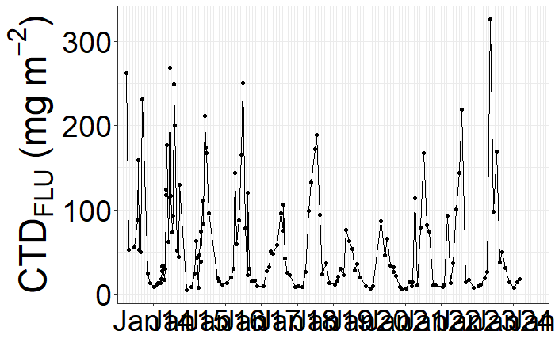

```r
int_chl %>%
  ggplot(aes(x = date, y = avg_int)) +
  geom_line() +
  geom_point() +
  scale_x_date(breaks = seq(as.Date("2014-01-01"), as.Date("2025-01-01"),
                            by = "1 year"), date_minor_breaks = "1 month",
               expand = c(0, 0),
               date_labels = "%b%y",
               limits = c(as.Date("2013-01-01"), as.Date("2025-01-01"))) +
  theme_bw() +
  labs(y = bquote(CTD[FLU]~"(mg" ~ m^-2*")")) +
  theme(text = element_text(size = 35), #35
        axis.text = element_text(color = "black"),
        axis.title.x = element_blank())

ggsave(here("figures", "timeseries_integrated_ctd_fluorescence2.png"),
        width = 16, height = 7, dpi = 300)
```

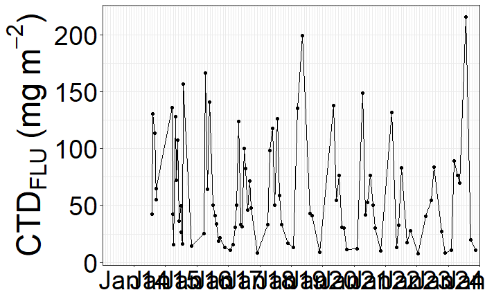

```r
int_chl_r1 %>%
  ggplot(aes(x = date, y = avg_int)) +
  geom_line() +
  geom_point() +
  scale_x_date(breaks = seq(as.Date("2014-01-01"), as.Date("2025-01-01"),
                            by = "1 year"), date_minor_breaks = "1 month",
               expand = c(0, 0),
               date_labels = "%b%y",
               limits = c(as.Date("2013-01-01"), as.Date("2025-01-01"))) +
  theme_bw() +
  labs(y = bquote(CTD[FLU]~"(mg" ~ m^-2*")")) +
  theme(text = element_text(size = 35), #35
        axis.text = element_text(color = "black"),
        axis.title.x = element_blank())

ggsave(here("figures", "timeseries_integrated_ctd_fluorescence_rvrs1.png"),
        width = 16, height = 7, dpi = 300)
```

```r
int_box <- int_chl %>%
  mutate(month = lubridate::month(date),
         year = lubridate::year(date)) %>%
  ggplot(aes(x = as.factor(month), y = avg_int)) +
  geom_boxplot() +
  geom_point(aes(fill = as.factor(year)), pch = 21, size = 5) +
  scale_fill_viridis_d() +
  labs(fill = NULL) +
  theme_bw() +
  labs(y = bquote(CTD[FLU]~"(mg" ~ m^-2*")")) +
  theme(text = element_text(size = 35), #35
        axis.text = element_text(color = "black"),
        axis.title.x = element_blank(),
        legend.position = c(0.95, 0.6))

ggsave(here("figures", "timeseries_integrated_monthly_climatology.png"),
        width = 16, height = 7, dpi = 300)
```

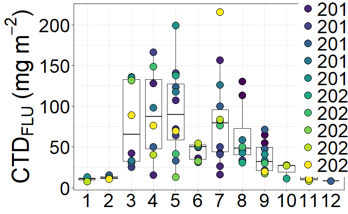

```r
int_chl_r1 %>%
  mutate(month = lubridate::month(date),
         year = lubridate::year(date)) %>%
  ggplot(aes(x = as.factor(month), y = avg_int)) +
  geom_boxplot() +
  geom_point(aes(fill = as.factor(year)), pch = 21, size = 5) +
  scale_fill_viridis_d() +
  labs(fill = NULL) +
  theme_bw() +
  labs(y = bquote(CTD[FLU]~"(mg" ~ m^-2*")")) +
  theme(text = element_text(size = 35), #35
        axis.text = element_text(color = "black"),
        axis.title.x = element_blank(),
        legend.position = c(0.95, 0.6))

ggsave(here("figures", "timeseries_integrated_monthly_climatology_rvrs1.png"),
        width = 16, height = 7, dpi = 300)
```

```r
int_chl_merge <- int_chl %>%
  mutate(station = "KC10")

int_chl_r1_merge <- int_chl_r1 %>%
  mutate(station = "RVRS01")

int_merge <- rbind(int_chl_merge, int_chl_r1_merge)
```

```r
int_chl_merge <- int_merge %>%
  mutate(month = lubridate::month(date),
         year = lubridate::year(date)) %>%
  ggplot(aes(x = as.factor(month), y = avg_int, fill = station)) +
  geom_boxplot() +
  labs(fill = NULL) +
  ggsci::scale_fill_npg() +
  theme_bw() +
  labs(y = bquote(CTD[FLU]~"(mg" ~ m^-2*")")) +
  theme(text = element_text(size = 35), #35
        axis.text = element_text(color = "black"),
        axis.title.x = element_blank(),
        legend.position = c(0.93, 0.9))

ggsave(here("figures", "timeseries_integrated_monthly_climatology_kc10_rvrs1.png"),
        width = 16, height = 7, dpi = 300)
```

```r
ctd <- ctd %>%
  mutate(month = lubridate::month(date),
         year = lubridate::year(date)) %>%
  mutate(season = case_when(month == 12 | month == 1 | month == 2 ~ "Winter",
                            month >= 3 & month <= 5 ~ "Spring",
                            month >= 6 & month <= 8 ~ "Summer",
                            month >= 9 & month <= 12 ~ "Autumn",)) %>%
  relocate(season, .after = month)

#I want to push December from each year to winter of the next year
ctd <- ctd %>%
  mutate(year = case_when(season == "Winter" & month == 12 ~ year+1,
                           TRUE ~ as.numeric(year)))

#Order locations from fjord to shelf
order_loc_seas <- c("Winter", "Spring", "Summer", "Autumn")

#Chemtax - Specify order of phyto groups for figures
ctd <- arrange(mutate(ctd,
                         season = factor(season, levels = order_loc_seas)))
```

```r
formatter <- function(...){
  function(x) format(round(x, 1), ...)
}

ctd_dm <- ctd %>%
  filter(pres >= 0 & pres <= 50) %>%
  group_by(date, pres) %>%
  summarise(flu = mean(flu)) %>%
  ungroup()
ctd_dm %>%
  mutate(month = lubridate::month(date),
         year = lubridate::year(date)) %>%
  filter(month > 4 & month < 9) %>%
  ggplot(aes(y = pres, x = flu)) +
  geom_line(aes(group = date, color = as.factor(year)),
            orientation = "y", size = 2) +
  facet_grid(. ~ month, scales = "free_x") +
  scale_y_reverse() +
  ylim(50, 0) +
  labs(x = bquote("CTD Fluorescence (mg"~m^-3*")"),
       y = "Depth (m)") +
  theme_bw() +
  scale_color_viridis_d() +
  scale_x_continuous(limits = c(0, NA), expand = c(0, 0),
                     labels = formatter(nsmall = 1)) +
  theme_bw() +
  theme(strip.background = element_blank(),
        text = element_text(size = 25),
        axis.text = element_text(colour = "black"),
        legend.title = element_blank(),
        # legend.position = c(0.07, 0.95),
        panel.spacing.x = unit(2, "lines"))
```

```
Using `size` aesthetic for lines was deprecated in ggplot2 3.4.0.Scale for y is already present.
```

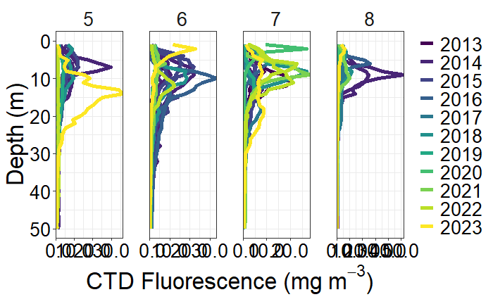

```r
ggsave(here("figures", "ctd_profiles_2.png"),
        width = 16, height = 13, dpi = 300)
```

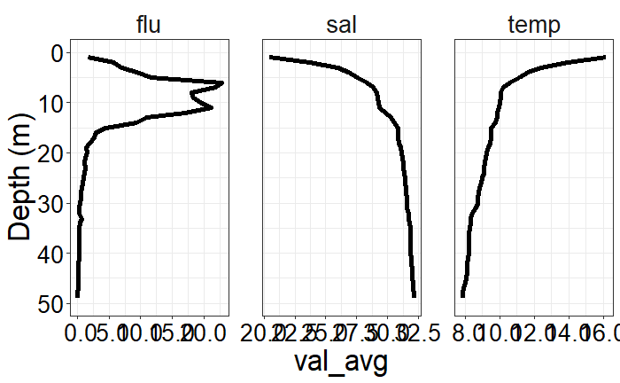

```r
dino_prof <- ctd %>%
  filter(date == "2022-07-28" | date == "2021-08-05") %>%
  filter(pres < 50) %>%
  select(date, pres, flu, sal, temp) %>%
  pivot_longer(c(flu:temp), names_to = "par", values_to = "val") %>%
  group_by(date, par, pres) %>%
  summarise(val_avg = mean(val)) %>%
  ungroup()
dino_prof %>%
  filter(date == "2022-07-28") %>%
  ggplot(aes(y = pres, x = val_avg)) +
  geom_line(aes(group = date),
            orientation = "y", size = 2) +
  facet_grid(. ~ par, scales = "free") +
  scale_y_reverse() +
  ylim(50, 0) +
  labs(
    # x = bquote("CTD Fluorescence (mg"~m^-3*")"),
       y = "Depth (m)") +
  theme_bw() +
  scale_color_viridis_d() +
  scale_x_continuous(
    # limits = c(0, NA), expand = c(0, 0),
                     labels = formatter(nsmall = 1)) +
  theme_bw() +
  theme(strip.background = element_blank(),
        text = element_text(size = 25),
        axis.text = element_text(colour = "black"),
        legend.title = element_blank(),
        # legend.position = c(0.07, 0.95),
        panel.spacing.x = unit(2, "lines"))
ggsave(here("figures", "ctd_profiles_dino.png"),
        width = 12, height = 10, dpi = 300)
```

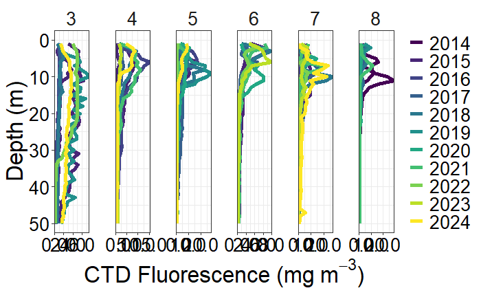

```r
ctd_dm_r1 <- ctd_r1 %>%
  filter(pres >= 0 & pres <= 50) %>%
  group_by(date, pres) %>%
  summarise(flu = mean(flu)) %>%
  ungroup()
ctd_dm_r1 %>%
  mutate(month = lubridate::month(date),
         year = lubridate::year(date)) %>%
  filter(month > 2 & month < 9) %>%
  ggplot(aes(y = pres, x = flu)) +
  geom_line(aes(group = date, color = as.factor(year)),
            orientation = "y", size = 2) +
  facet_grid(. ~ month, scales = "free_x") +
  scale_y_reverse() +
  ylim(50, 0) +
  labs(x = bquote("CTD Fluorescence (mg"~m^-3*")"),
       y = "Depth (m)") +
  theme_bw() +
  scale_color_viridis_d() +
  scale_x_continuous(limits = c(0, NA), expand = c(0, 0),
                     labels = formatter(nsmall = 1)) +
  theme_bw() +
  theme(strip.background = element_blank(),
        text = element_text(size = 25),
        axis.text = element_text(colour = "black"),
        legend.title = element_blank(),
        # legend.position = c(0.07, 0.95),
        panel.spacing.x = unit(2, "lines"))
ggsave(here("figures", "ctd_profiles_rvrs01.png"),
        width = 16, height = 13, dpi = 300)
```

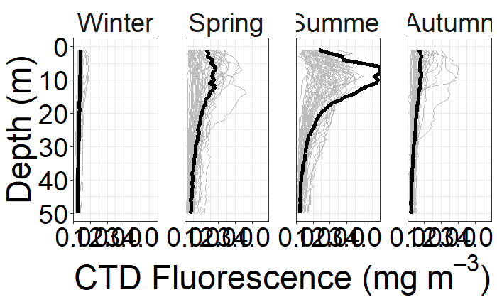

```r
ctd %>%
  filter(pres >= 0 & pres <= 50) %>%
  mutate(lubridate::month(date)) %>%
  group_by(season, pres) %>%
  mutate(flu_med = median(flu, na.rm = T)) %>%
  ungroup() %>%
  ggplot() +
  geom_line(aes(y = pres, x = log1p(flu), group = castpk, color = year),
            orientation = "y", size = 0.5,
            color = "grey"
            ) +
  geom_line(aes(y = pres, x = flu_med), orientation = "y", size = 2,
            color = "black") +
  facet_grid(. ~ season) +
  scale_y_reverse() +
  ylim(50, 0) +
  labs(x = bquote("CTD Fluorescence (mg"~m^-3*")"),
       y = "Depth (m)") +
  theme_bw() +
  scale_color_viridis_c() +
  scale_x_continuous(limits = c(0, NA), expand = c(0, NA),
                     labels = formatter(nsmall = 1)) +
  theme_bw() +
  theme(strip.background = element_blank(),
        text = element_text(size = 35),
        axis.text = element_text(colour = "black"),
        legend.title = element_blank(),
        # legend.position = c(0.07, 0.95),
        panel.spacing.x = unit(2, "lines"))
ggsave(here("figures", "ctd_profiles_median_season.png"),
        width = 16, height = 13, dpi = 300)
```

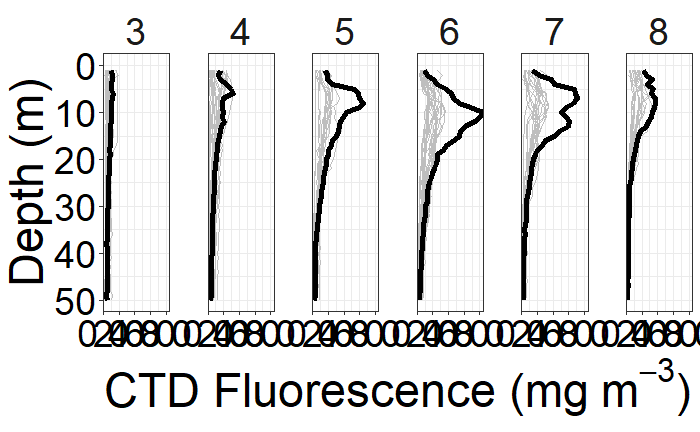

```r
ctd %>%
  filter(pres >= 0 & pres <= 50) %>%
  mutate(lubridate::month(date)) %>%
  filter(season == "Spring" | season == "Summer") %>%
  group_by(month, pres) %>%
  mutate(flu_med = median(flu, na.rm = T)) %>%
  ungroup() %>%
  ggplot() +
  geom_line(aes(y = pres, x = log1p(flu), group = castpk, color = year),
            orientation = "y", size = 0.5,
            color = "grey"
            ) +
  geom_line(aes(y = pres, x = flu_med), orientation = "y", size = 2,
            color = "black") +
  facet_grid(. ~ month) +
  scale_y_reverse() +
  ylim(50, 0) +
  labs(x = bquote("CTD Fluorescence (mg"~m^-3*")"),
       y = "Depth (m)") +
  theme_bw() +
  scale_color_viridis_c() +
  scale_x_continuous(limits = c(0, NA), expand = c(0, NA),
                     labels = formatter(nsmall = 1)) +
  theme_bw() +
  theme(strip.background = element_blank(),
        text = element_text(size = 35),
        axis.text = element_text(colour = "black"),
        legend.title = element_blank(),
        # legend.position = c(0.07, 0.95),
        panel.spacing.x = unit(2, "lines"))
ggsave(here("figures", "ctd_profiles_median_month_spring_summer.png"),
        width = 16, height = 13, dpi = 300)
```

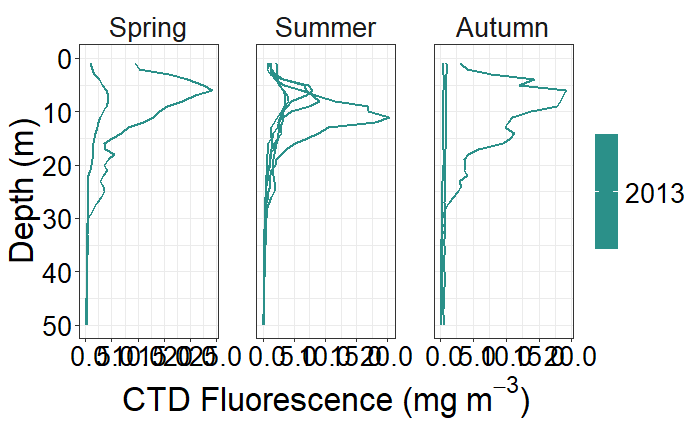

```r
ctd %>%
  filter(pres >= 0 & pres <= 50 & year == 2013) %>%
  ggplot(aes(y = pres, x = flu)) +
  geom_line(aes(group = castpk, color = year),
            orientation = "y", size = 1) +
  facet_grid(. ~ season, scales = "free_x") +
  scale_y_reverse() +
  ylim(50, 0) +
  labs(x = bquote("CTD Fluorescence (mg"~m^-3*")"),
       y = "Depth (m)") +
  theme_bw() +
  scale_color_viridis_c() +
  scale_x_continuous(limits = c(0, NA),
                     labels = formatter(nsmall = 1)) +
  theme_bw() +
  theme(strip.background = element_blank(),
        text = element_text(size = 25),
        axis.text = element_text(colour = "black"),
        legend.title = element_blank(),
        # legend.position = c(0.07, 0.95),
        panel.spacing.x = unit(2, "lines"))
ggsave(here("figures", "ctd_profiles_2013.png"),
        width = 16, height = 13, dpi = 300)
```

```r
ctd_2023 <- ctd %>%
  filter(pres >= 0 & pres <= 50 & year == 2023)
```

```r
ctd_max <- ctd %>%
  filter(pres <= 30) %>%
  group_by(castpk) %>%
  filter(flu == max(flu)) %>%
  ungroup() %>%
  group_by(date) %>%
  summarise(med_max = median(pres)) %>%
  ungroup() %>%
  mutate(month = lubridate::month(date),
         station = "KC10")

ctd_max_r1 <- ctd_r1 %>%
  filter(pres <= 30) %>%
  group_by(castpk) %>%
  filter(flu == max(flu)) %>%
  ungroup() %>%
  group_by(date) %>%
  summarise(med_max = median(pres)) %>%
  ungroup() %>%
  mutate(month = lubridate::month(date),
         station = "RVRS01")

ctd_max_merge <- rbind(ctd_max, ctd_max_r1)
```

```r
max_box <- ctd_max %>%
  ggplot(aes(x = as.factor(month), y = med_max)) +
  geom_boxplot() +
  scale_y_reverse() +
  theme_bw() +
  labs(y = bquote(Max[FLU]~"(Depth" ~ m^-1*")")) +
  theme(text = element_text(size = 35), #35
        axis.text = element_text(color = "black"),
        axis.title.x = element_blank())

ggsave(here("figures", "timeseries_chla_max_depth.png"),
        width = 16, height = 7, dpi = 300)
```

```r
max_box_merge <- ctd_max_merge %>%
  ggplot(aes(x = as.factor(month), y = med_max, fill = station)) +
  geom_boxplot() +
  scale_y_reverse() +
  ggsci::scale_fill_npg() +
  theme_bw() +
  labs(y = bquote(Max[FLU]~"(Depth" ~ m^-1*")")) +
  theme(text = element_text(size = 35), #35
        axis.text = element_text(color = "black"),
        axis.title.x = element_blank(),
        legend.position = "none")

ggsave(here("figures", "timeseries_chla_max_depth_kc10_rvrs01.png"),
        width = 16, height = 7, dpi = 300)
```

```r
int_dep <- int_box / max_box
```

|  | t | l | b | r |
| --- | --- | --- | --- | --- |
| 1: | 1 | 1 | 1 | 1 |
| 2: | 1 | 2 | 1 | 2 |

```r
int_dep_merge <- int_chl_merge/max_box_merge
```

|  | t | l | b | r |
| --- | --- | --- | --- | --- |
| 1: | 1 | 1 | 1 | 1 |
| 2: | 1 | 2 | 1 | 2 |

```r
ggsave(here("figures", "box_monthly_int_max_clim.png"), int_dep,
        width = 16, height = 12, dpi = 300)

ggsave(here("figures", "box_monthly_int_max_clim_kc10_rvrs01.png"), int_dep_merge,
        width = 16, height = 12, dpi = 300)
```

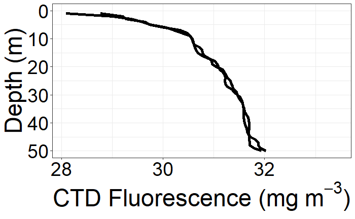

```r
ctd_2016 <- ctd %>%
  filter(year == 2016 & season == "Summer")

ctd_2016_ex <- ctd_2016 %>%
  filter(date == "2016-06-30")

ctd_2016_ex %>%
  ggplot() +
  geom_line(aes(y = pres, x = sal, group = castpk), orientation = "y", size = 2,
            color = "black") +
  scale_y_reverse() +
  ylim(50, 0) +
  labs(x = bquote("CTD Fluorescence (mg"~m^-3*")"),
       y = "Depth (m)") +
  theme_bw() +
  scale_color_viridis_c() +
  # scale_x_continuous(limits = c(0, NA), expand = c(0, NA),
  #                    labels = formatter(nsmall = 1)) +
  theme_bw() +
  theme(strip.background = element_blank(),
        text = element_text(size = 35),
        axis.text = element_text(colour = "black"),
        legend.title = element_blank(),
        # legend.position = c(0.07, 0.95),
        panel.spacing.x = unit(2, "lines"))
```

```r
#Can I compare KC10 and FZH01 to complete the time-series?
comp_kc <- kc_qc %>%
  filter(site_id == "KC10") %>%
  select(date, depth, filter_type2, avg_chla_k = avg_chla, sum_k = sum)

comp_fh <- kc_qc %>%
  filter(site_id == "FZH01") %>%
  select(date, depth, filter_type2, avg_chla_f = avg_chla, sum_f = sum)

comp <- comp_kc %>%
  full_join(comp_fh)
```

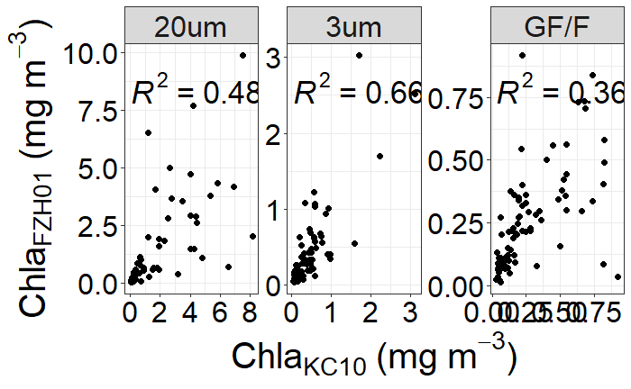

```r
comp %>%
  filter(!is.na(avg_chla_k)) %>%
  filter(!is.na(avg_chla_f)) %>%
  ggplot(aes(x = avg_chla_k, y = avg_chla_f)) +
  geom_point(size = 2) +
  ggpubr::stat_cor(aes(label = paste(..rr.label.., ..p.label.., sep = "~`,`~")),
                   p.accuracy = 0.001, size = 9) +
  labs(x = bquote(Chla[KC10] ~ "("*mg~m^-3*")"),
       y = bquote(Chla[FZH01] ~ "("*mg~m^-3*")")) +
  facet_wrap(~filter_type2, scales = "free") +
  theme_bw() +
  theme(text = element_text(size = 30), #35
        axis.text = element_text(color = "black"))

ggsave(here("figures", "comparison.png"),
        width = 14, height = 6, dpi = 300)
```

```r
clim_m <- kc_qc %>%
  group_by(month, depth, filter_type2) %>%
  summarise(med_sf = median(avg_chla),
            n = n()) %>%
  ungroup()
clim_y <- kc_qc %>%
  group_by(year, depth, filter_type2) %>%
  summarise(med_sf = median(avg_chla),
            n = n()) %>%
  ungroup()
```

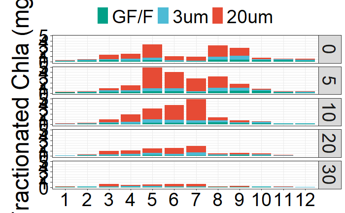

```r
#Looking at monthly medians by filter type and depth
clim_m %>%
  ggplot() +
  geom_bar(aes(x = as.factor(month), y = med_sf, fill = filter_type2),
           position = "stack", stat = "identity") +
  ggsci::scale_fill_npg() +
  facet_grid(depth ~ .) +
  theme_bw() +
  labs(y = bquote("Size Fractionated Chla (mg" ~ m^-3*")"),
       fill = "Group") +
  theme(legend.position = "top",
        legend.direction = "horizontal",
        legend.title = element_blank(),
        text = element_text(size = 35), #35
        axis.text = element_text(color = "black"),
        axis.title.x = element_blank()) +
  guides(fill = guide_legend(nrow = 1, reverse = TRUE))

ggsave(here("figures", "climatology_monthly.png"),
        width = 16, height = 14, dpi = 300)
```

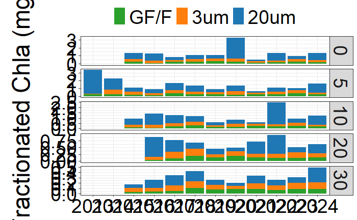

```r
#Looking at annual medians by depth, but I don't think this really shows much.
clim_y %>%
  ggplot() +
  # geom_area() +
  geom_bar(aes(x = as.factor(year), y = med_sf, fill = filter_type2),
           position = "stack", stat = "identity") +
  # geom_smooth(aes(x = date, y = sum, color = as.factor(year)),
  #             method = "loess", span = 0.05) +
  ggsci::scale_fill_d3() +
  facet_grid(depth ~ ., scales = "free_y") +
  # scale_x_date(breaks = seq(as.Date("2014-01-01"), as.Date("2025-01-01"),
  #                           by = "1 year"), date_minor_breaks = "1 month",
  #              expand = c(0, 0),
  #              date_labels = "%b%y",
  #              limits = c(as.Date("2014-01-01"), as.Date("2025-01-01"))) +
  theme_bw() +
  labs(y = bquote("Size Fractionated Chla (mg" ~ m^-3*")"),
       fill = "Group") +
  theme(legend.position = "top",
        legend.direction = "horizontal",
        legend.title = element_blank(),
        text = element_text(size = 35), #35
        axis.text = element_text(color = "black"),
        axis.title.x = element_blank()) +
  guides(fill = guide_legend(nrow = 1, reverse = TRUE))

ggsave(here("figures", "climatology_yearly.png"),
        width = 16, height = 14, dpi = 300)
```

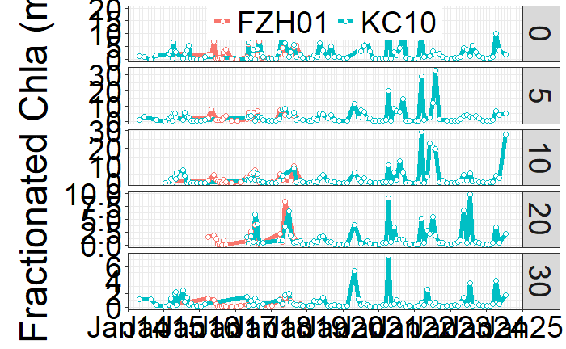

```r
kc_bulk %>%
  filter(depth < 31) %>%
  ggplot(aes(x = date, y = bulk, color = site_id)) +
  # geom_area() +
  geom_line(size = 2) +
  geom_point(pch = 21, fill = "white", size = 2) +
  ggsci::scale_fill_d3() +
  facet_grid(depth ~ ., scales = "free_y") +
  scale_x_date(breaks = seq(as.Date("2014-01-01"), as.Date("2025-01-01"),
                            by = "1 year"), date_minor_breaks = "1 month",
               expand = c(0, 0),
               date_labels = "%b%y",
               limits = c(as.Date("2014-01-01"), as.Date("2025-01-01"))) +
  theme_bw() +
  labs(y = bquote("Size Fractionated Chla (mg" ~ m^-3*")"),
       fill = "Group") +
  theme(legend.position = c(0.5, 0.95),
        legend.direction = "horizontal",
        legend.title = element_blank(),
        text = element_text(size = 35), #35
        axis.text = element_text(color = "black"),
        axis.title.x = element_blank()) +
  guides(fill = guide_legend(nrow = 1, reverse = TRUE))

ggsave(here("figures", "timeseries_bulk.png"),
        width = 16, height = 14, dpi = 300)
```

Ideas

I think the idea is to try to find large-scale linkages with things like ENSO etc.

How many in-situ samples can I leverage across space and time. Maybe this isn’t relevent as there is so much inconsistency. Wiley’s idea is to use satellite.

If I focus on KC10, can the size-fractionated data highlight some differences in years and depths, potentially through clustering or ordinations. Is it possible that heatwave years had more smaller species or less biomass?

What about fluorescence profiles and integrated chlorophyll? This would give the depth aspect not covered by satellite imagery.

Clean up the KC10 buoy fluorescence records to get a good idea on temporal variability with freshwater, temperature and PAR links? I think 2021, 2022 and 2024 are salvageable, although 2022 needs major spike removal. Is there a point in this though, with Wiley being able to pick up a lot of this information using the CO2 data?